# *R Markdown* Final Project

Justin Chow

Final Project - Price Discrimination

This is my version of Econ 42 Final Project

```
## [1] "C:/Users/14087/Documents/SCU_Fall2020/Econ 42"
```

```
##
## Descriptive Statistics for Price of Entrees
## ============================================================
## Statistic  N   Mean  St. Dev.  Min  Pctl(25) Pctl(75)  Max
## ------------------------------------------------------------
## pentree   321 1.348   0.646   0.490  0.950    1.940   3.950
## prpblck   331 0.131   0.198   0.000  0.013    0.156   0.982
## incomes   331 4.805   1.356   1.592  3.921    5.638   13.653
## prpncar   331 0.119   0.123   0.006  0.043    0.129   0.627
## hrsopen   331 14.418  2.779     7     11.5      16      24
## ------------------------------------------------------------
##
## Descriptive Statistics for Price of Entrees
## ====
## TRUE
## ----
##
## Descriptive Statistics for Price of Entrees
## =
## 3
## -
```

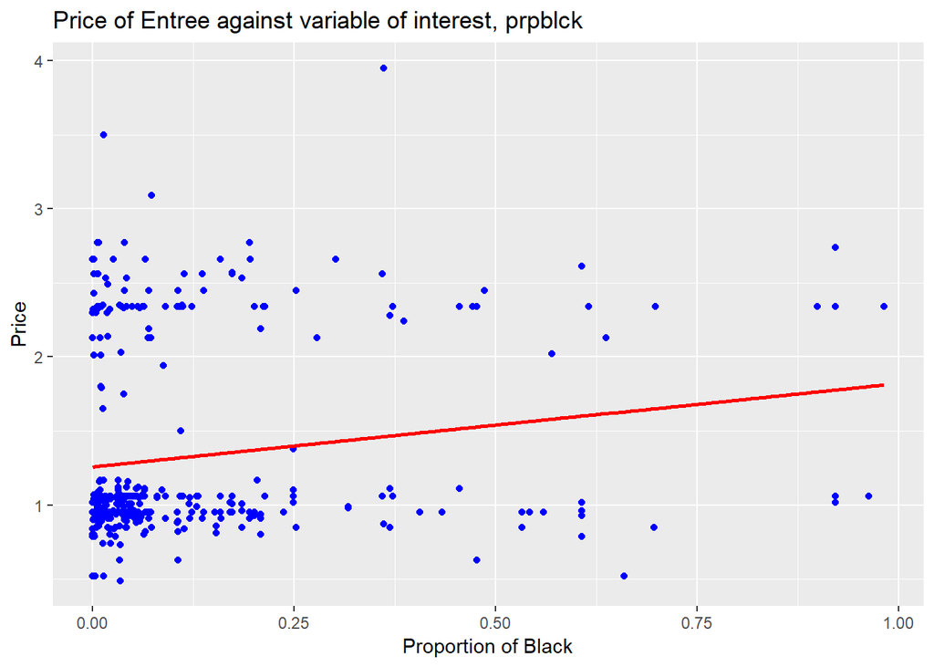

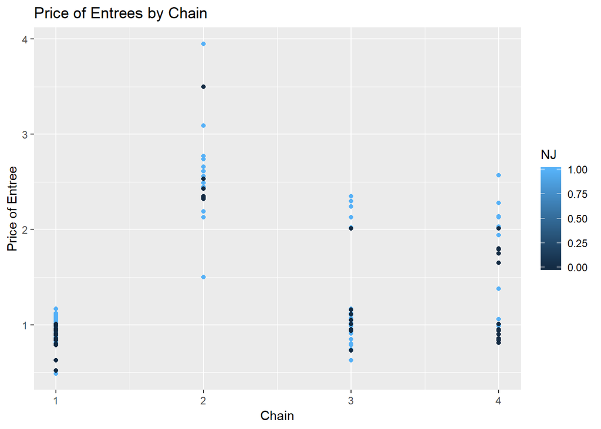

### Part 1. Exploratory Data Analysis

**1. Use stargazer to create a table of descriptive statistics for incomes, prpblck, prpncar, and hrsopen. Briefly describe what you learn about the data.**

In this table of descriptive statistics, the average income in NJ is 4.805 dollars (in thousands) so income tends to average right in the middle of the scale varying from the line of best fit by 1.356 dollars (in thousands). Prpblck has a mean of 0.131 so black people make up an average of 13.1% of the total population in NJ, which means prpblck varies from the line of best fit by 0.198 or 19.8%. Prpncar has a mean of 0.119 so people with no car make up an average of 11.9% of the total population in NJ and prpncar varies from the line of best fit by 0.123 or 12.3%. Hrsopen has a mean of 14.418 hours so most fast-food restaurants are open for an average of 14 hours, which means for every hour varying from the line of best fit by 2.779 hours. Price of entree has a mean of $1.35 and the price of the entree deviates from the line of best fit on average by $0.65.

**2. Use ggplot to create a scatterplot for price of entrees against prpblck. Is there a relationship between price of entrees and the proportion of black. Is the direction of the association what you expected? Why or why not?**

There is a clear positive slope showing positive correlation between the price of entrees and prpblck. This means that, on average, the higher proportion of blacks there are in a given area the higher the price of entrees. The larger distribution of prices within the two dollar range causes the relationship to be positively correlated between price of entrees and prpblck. We did expect this slight positive correlation because of our preconceived hypothesis that price discrimination is common.

```
##
## Regression Model of Price of Entree
## ==============================================================================
##                                        Dependent variable:
##                     ----------------------------------------------------------
##                                              pentree
##                       (1)      (2)       (3)       (4)       (5)       (6)
## ------------------------------------------------------------------------------
## prpblck             0.551***  0.400*  0.715***   0.426**   0.462**    0.172
##                     (0.200)  (0.220)   (0.247)   (0.174)   (0.207)   (0.210)
##
## incomes                      -0.043*  -0.090***  -0.036    -0.036     -0.010
##                              (0.025)   (0.031)   (0.026)   (0.024)   (0.015)
##
## prpncar                               -1.128**   -0.304    -0.181    -0.330*
##                                        (0.454)   (0.391)   (0.341)   (0.200)
##
## log(hrsopen)                                    -2.066*** -1.698***   -0.047
##                                                  (0.198)   (0.220)   (0.240)
##
## BK                                                        -0.242*** -0.171***
##                                                            (0.066)   (0.050)
##
## I(prpblck * BK)                                           -0.645***   -0.159
##                                                            (0.238)   (0.204)
##
## KFC                                                                  1.294***
##                                                                      (0.090)
##
## I(prpblck * KFC)                                                      -0.063
##                                                                      (0.212)
##
## Constant            1.274*** 1.502*** 1.821***  6.968***  6.105***   1.355**
##                     (0.040)  (0.144)   (0.195)   (0.498)   (0.539)   (0.618)
##
## ------------------------------------------------------------------------------
## Observations          321      321       321       321       321       321
## R2                   0.029    0.035     0.052     0.430     0.483     0.797
## Adjusted R2          0.026    0.029     0.044     0.423     0.473     0.792
## Residual Std. Error  0.638    0.637     0.632     0.491     0.469     0.295
## F Statistic         9.532*** 5.784*** 5.854***  59.615*** 48.802*** 153.085***
## ==============================================================================
## Note:                                              *p<0.1; **p<0.05; ***p<0.01
```

```
##
## Regression Model of Price of Entree
## ==============================================================================
##                                        Dependent variable:
##                     ----------------------------------------------------------
##                                              pentree
##                        (1)      (2)      (3)       (4)       (5)       (6)
## ------------------------------------------------------------------------------
## prpblck             0.564***  0.483**  0.750*** 0.588***  0.623***    0.162
##                      (0.197)  (0.212)  (0.238)   (0.182)   (0.213)   (0.208)
##
## incomes                        -0.026  -0.065**  -0.028    -0.031     -0.004
##                               (0.024)  (0.028)   (0.022)   (0.022)   (0.015)
##
## prpncar                                -0.921**  -0.550    -0.467    -0.317*
##                                        (0.403)   (0.370)   (0.351)   (0.184)
##
## log(hrsopen)                                    -2.026*** -1.662***   -0.052
##                                                  (0.162)   (0.190)   (0.198)
##
## BK                                                        -0.230*** -0.199***
##                                                            (0.062)   (0.047)
##
## I(prpblck * BK)                                           -0.586***   -0.051
##                                                            (0.222)   (0.200)
##
## KFC                                                                  1.300***
##                                                                      (0.078)
##
## I(prpblck * KFC)                                                      -0.042
##                                                                      (0.211)
##
## Constant            1.258***  1.390*** 1.650*** 6.814***  5.966***   1.331**
##                      (0.036)  (0.130)  (0.173)   (0.428)   (0.474)   (0.517)
##
## ------------------------------------------------------------------------------
## Observations           397      397      397       397       397       397
## R2                    0.026    0.029    0.040     0.426     0.467     0.796
## Adjusted R2           0.024    0.024    0.032     0.420     0.458     0.792
## Residual Std. Error   0.636    0.636    0.633     0.490     0.474     0.293
## F Statistic         10.630*** 5.785*** 5.402*** 72.642*** 56.858*** 189.736***
## ==============================================================================
## Note:                                              *p<0.1; **p<0.05; ***p<0.01
```